# analytic_solution

## Analytic Solution to Temperature Model

$$ \left( \begin{array}{c} dT_t \\ dS_{t} \\ \end{array} \right) = \left( \begin{array}{c} \dot{\mu}(t) + \alpha(\mu(t) - T_{t}) \\ \dot{\sigma}(t) + \beta(\sigma(t) - S_{t}) \\ \end{array} \right) dt + \left( \begin{array}{c} S_{t} \cdot \sqrt{2\alpha} & 0 \\ 0 & \chi \cdot \sqrt{2\beta} \\ \end{array} \right) \left( \begin{array}{c} dW^{(1)}_{t} \\ dW^{(2)}_{t} \\ \end{array} \right)$$$$ S_{0} \sim N(\sigma(0), \chi^{2}) $$

It is fairly easy to show that, even for this time-dependent Ornstein-Ulhenbeck process, $S_{t} \sim N(\sigma(t), \chi^{2})$,

\begin{align*} & dS_{t} = \left[\dot{\sigma}(t) + \beta (\sigma(t) - S_{t}) \right] dt + \chi \cdot \sqrt{2 \beta}~dW_{t}, \\ & dZ_{t} = \left[\beta S_{t} e^{\beta t} + \beta e^{\beta t} \left(\sigma(t) - S_{t}\right) + e^{\beta t} \dot{\sigma}(t) \right] dt + \chi \cdot \sqrt{2 \beta} e^{\beta t} dW_{t}, & (\text{Itô's Lemma, } Z_{t} = S_{t}e^{\beta t}) \\ & dZ_{t} = \left[\beta e^{\beta t} \sigma(t) + e^{\beta t} \dot{\sigma}(t) \right] dt + \chi \cdot \sqrt{2 \beta} e^{\beta t} dW_{t}, \\ & \int_{0}^{t} dZ_{s} = Z_{t} - Z_{0} = \beta \int_{0}^{t} e^{\beta s}\sigma(s) ds + \int_{0}^{t} e^{\beta s} \dot{\sigma}(s) ds + \chi\cdot\sqrt{2\beta} \int_{0}^{t} e^{\beta s} dW_{s}, \\ & Z_{t} - Z_{0} = e^{\beta t} \sigma(t) - \sigma(0) + \chi\cdot\sqrt{2\beta} \int_{0}^{t} e^{\beta s} dW_{s}, \\ & S_{t} e^{\beta t} = S_{0} + e^{\beta t} \sigma(t) - \sigma(0) + \chi\cdot\sqrt{2\beta} \int_{0}^{t} e^{\beta s} dW_{s}, \\ & S_{t} = \sigma(t) + e^{-\beta t} (S_{0} - \sigma(0)) + \chi\cdot\sqrt{2\beta} \int_{0}^{t} e^{\beta (s-t)} dW_{s}. \end{align*}

Considering now the quantity, $\int_{0}^{t} e^{\beta (s-t)} dW_{s}$, as the integrand is deterministic, this is Gaussian, with mean $0$ and variance

\begin{align*} \mathbb{V}\left[ \int_{0}^{t} e^{\beta (s-t)} dW_{s} \right] &= \int_{0}^{t} \mathbb{E}\left[\left(e^{\beta (s-t)}\right)^{2}\right] ds & \text{(Ito's Isometry)} \\ & = \frac{1}{2\beta} (1 - e^{-2\beta t}) \\ &\implies \chi\cdot\sqrt{2\beta} \int_{0}^{t} e^{\beta (s-t)} dW_{s} \sim N(0, \chi^{2}(1 - e^{-2 \beta t}))\\ &\implies \mathbb{V}[S_{t}] = e^{-2 \beta t} \mathbb{V}[S_{0}] + \chi^{2}(1 - e^{-2 \beta t})\\ \mathbb{V}[S_{0}] = \chi^{2} &\implies \mathbb{V}[S_{t}] = \chi^{2}. \end{align*}

We now aim to derive an analytic form of the temperature $T_{t}$ driven by stochastic standard deviation,

There are a number of ways I will attempt to do this,

# 1. Expectation over the path space

If we consider a single path realisation, $\omega$, of the stochastic volatility, which we denote by $S_{t}^{\omega}$. Under this path realisation, we have a deterministic system,

\begin{align*} & dT_{t} = \left[\dot{\mu}(t) + \alpha (\mu(t) - T_{t}) \right] dt + \sqrt{2\alpha} S_{t}^{\omega}~dW_{t}, \\ & dY_{t} = \left[\alpha T_{t} e^{\alpha t} + \alpha e^{\alpha t} \left(\mu(t) - T_{t}\right) + e^{\alpha t} \dot{\mu}(t) \right] dt + \sqrt{2\alpha} S_{t}^{\omega} e^{\alpha t} dW_{t}, & (\text{Itô's Lemma, } Y_{t} = T_{t}e^{\alpha t}) \\ & dY_{t} = \left[\alpha e^{\alpha t} \mu(t) + e^{\alpha t} \dot{\mu}(t) \right] dt + \sqrt{2\alpha} S_{t}^{\omega}e^{\alpha t} dW_{t}, \\ & \int_{0}^{t} dY_{s} = Y_{t} - Y_{0} = \alpha \int_{0}^{t} e^{\alpha s}\mu(s) ds + \int_{0}^{t} e^{\alpha s} \dot{\mu}(s) ds + \sqrt{2\alpha} \int_{0}^{t} e^{\alpha s} S_{s}^{\omega} dW_{s}, \\ & Y_{t} - Y_{0} = e^{\alpha t} \mu(t) - \mu(0) + \sqrt{2\alpha} \int_{0}^{t} e^{\alpha s} S_{s}^{\omega} dW_{s}, \\ & T_{t} e^{\alpha t} = T_{0} + e^{\alpha t} \mu(t) - \mu(0) + \sqrt{2\alpha} \int_{0}^{t} S_{t}^{\omega} e^{\alpha s} dW_{s}, \\ & T_{t} = \mu(t) + e^{-\alpha t} (T_{0} - \mu(0)) + \sqrt{2\alpha} \int_{0}^{t} S_{s}^{\omega} e^{\alpha (s-t)} dW_{s}. \end{align*}

Naturally, we initialise $T_{0} = \mu(0)$. Therefore, under this instance of the stochastic volatility, we have a deterministic integrand, therefore we can apply Ito's Isometry in a similar manner to before.

$$ T_{t} | \omega \sim N\left(\mu(t), \sqrt{2\alpha} \cdot e^{-2\alpha t} \int_{0}^{t} \left( S_{s}^{\omega} e^{\alpha s} \right)^{2} ds\right) $$

Now, to get the marginal distribution, of $T_{t}$ we can take an expectation over the path realisations,

$$ T_{t} \sim \mathbb{E}_{\omega}\left[T_{t} | \omega \right]. $$

Unfortunately, I'm not sure how to express this quantity further.

# 2. Ito's Isometry

In this part, I attempt to use Ito's Isometry to find an analytic form of the stochastic integral, with the stochastic volatility in the integrand. It's worth noting, as the stochastic volatility and the temperature process are driven by independent, uncorrelated, brownian motions, the integrand is independent of the increments. $(S_{t}~{\perp \!\!\! \perp} ~dW_{t}^{(1)})$.

Can I use Ito's Isometry to find the variance of $\int_{0}^{t} S_{s} e^{-\alpha(s - t)} ds$,

$$ \mathbb{V}\left[ \int_{0}^{t} S_{s} e^{-\alpha(s - t)} dW_{s} \right] \overset{(?)}{=} \int_{0}^{t} \mathbb{E}\left[ \left(S_{s} e^{-\alpha(s - t)} \right)^{2} \right] ds = \int_{0}^{t} \sigma^{2}(s) e^{-2\alpha(s - t)} ds .$$

Have I abused notation here, is the variance taken with respect to the probability space of the driving brownian motion and not with respect to the randomness of the integrand ($S_{t}$)?

However, even if this approach is valid, as the integrand is not determinsitic, I cannot find any theorems in the literature which show that this integral Gaussian (which in fairness I do not expect it to be), or even follows any known distribution.

# 3. Integrate

Finally we can consider the following,

\begin{align*} e^{-\alpha t} \int_{0}^{t} S_{s} e^{\alpha s} dW_{s} & = e^{-\alpha t} \int_{0}^{t} e^{-\beta s} Z_{s} e^{\alpha s} dW_{s} & Z_{t} = e^{\beta t}Z_{t} \\ & = e^{-\alpha t}\int_{0}^{t} \left(Z_{0} + \int_{0}^{s} dZ_{\gamma}\right) e^{(\alpha - \beta) s} dW_{s} & Z_{s} = Z_{0} + \int_{0}^{s}dZ_{\gamma} \\ & = e^{-\alpha t}\int_{0}^{t} \left(Z_{0} + e^{\beta t} \sigma(t) - \sigma(0) + \chi\cdot\sqrt{2\beta} \int_{0}^{s} e^{\beta \gamma} dW_{\gamma}\right) e^{(\alpha - \beta) s} dW_{s} \\ & = e^{-\alpha t}\int_{0}^{t} \left(e^{\beta s} \sigma(s) + \chi\cdot\sqrt{2\beta} \int_{0}^{s} e^{\beta \gamma} dW_{\gamma}\right) e^{(\alpha - \beta) s} dW_{s} & Z_{0} = \sigma(0) \\ & = e^{-\alpha t}\int_{0}^{t} \left(e^{\beta s} \sigma(s) + \chi\cdot\sqrt{2\beta} \int_{0}^{s} e^{\beta \gamma} dW_{\gamma}\right) e^{(\alpha - \beta) s} dW_{s} \\ & = e^{-\alpha t} \int_{0}^{t} \sigma(s) e^{\alpha s} dW_{s} + e^{-\alpha t} \chi\cdot\sqrt{2\beta} \int_{0}^{t} \int_{0}^{s} e^{\beta \gamma} dW_{\gamma} e^{(\alpha - \beta) s} dW_{s} \end{align*}

Now, considering these two quantities, we know the first integral is Gaussian. Using expectation properties of Ito stochastic integrals, we know this to be mean zero and the expectation is given by Ito's Isometry.

$$ e^{-\alpha t} \int_{0}^{t} \sigma(s) e^{\alpha s} dW_{s} \sim N(0, e^{-2 \alpha t}\int_{0}^{t} \sigma^{2}(s) e^{2\alpha s} ds). $$

Given $\sigma(t)$ is known, and furthermore, in our case polynomial, this can be determined analytically. Therefore, it remains to consider the final term,

$$ e^{-\alpha t} \chi\cdot\sqrt{2\beta} \int_{0}^{t} \int_{0}^{s} e^{\beta \gamma} dW_{\gamma} e^{(\alpha - \beta) s} dW_{s} $$

Considering only the integrand of the outer integral, \begin{align*} e^{(\alpha - \beta) s} \int_{0}^{s} e^{\beta \gamma} dW_{\gamma} &\sim e^{(\alpha - \beta) s} N\left(0, \int_{0}^{s} e^{2\beta \gamma} d\gamma \right) \\ &\sim e^{(\alpha - \beta) s} N\left(0, \frac{1}{2\beta} (e^{2 \beta s} - 1)\right) \\ &\sim e^{\alpha s} N\left(0, \frac{1}{2\beta} (1 - e^{-2 \beta s})\right) &&= e^{\alpha s} \frac{1}{\sqrt{2\beta}} W_{1 - e^{-2\beta s}} & (&\text{Relation between space and time rescaling of BM}) \end{align*}

So now, considering the full quantity,

\begin{align*} e^{-\alpha t} \chi\cdot\sqrt{2\beta} \int_{0}^{t} \int_{0}^{s} e^{\beta \gamma} dW_{\gamma} e^{(\alpha - \beta) s} dW_{s} &= e^{-\alpha t} \chi \int_{0}^{t} e^{\alpha s} W_{1-e^{-2\beta s}} dW_{s} \\ &= e^{-\alpha t} \chi \int_{0}^{t} e^{\alpha s} \sqrt{1-e^{-2\beta s}} W_{1} dW_{s} & (\text{Time Rescaling of integrand BM}) \\ &= W_{\chi^{2}}e^{-\alpha t} \int_{0}^{t} e^{\alpha s} \sqrt{1-e^{-2\beta s}} dW_{s} \\ &= W_{\chi^{2}} e^{-\alpha t} N\left(0, \int_{0}^{t} e^{2\alpha s} (1-e^{-2\beta s}) ds \right). & (\text{Ito's Isometry}) \\ \int_{0}^{t} e^{2\alpha s} (1-e^{-2\beta s}) ds &= \int_{0}^{t} e^{2\alpha s} ds - \int_{0}^{t} e^{2(\alpha - \beta) s} ds \\ &= \frac{1}{2\alpha}\left( e^{2 \alpha t} - 1\right) - \frac{1}{2(\alpha - \beta)} (e^{2(\alpha - \beta) t} - 1) \\ &= \frac{{\alpha - e^{-2 t \beta} \alpha - \beta + e^{-2 t \alpha} \beta}}{{2 \alpha^2 - 2 \alpha \beta}} = \frac{1}{2\alpha}\frac{{\alpha - e^{-2 t \beta} \alpha - \beta + e^{-2 t \alpha} \beta}}{{\alpha - \beta}} \\ &= \frac{1}{2\alpha}\left(1 - \frac{e^{-2 t \beta} \alpha - e^{-2 t \alpha} \beta}{\alpha - \beta} \right) \to \frac{1}{2\alpha} \text{ as } t \to \infty \text{ (*)}. \end{align*}

(*), this observation is not particularly relevant as we wish to model usually just the following season

$$ \implies e^{-\alpha t} \chi\cdot\sqrt{2\beta} \int_{0}^{t} \int_{0}^{s} e^{\beta \gamma} dW_{\gamma} e^{(\alpha - \beta) s} dW_{s} = W_{\chi^{2}} N\left(0, \frac{1}{2\alpha}\left(1 - \frac{e^{-2 t \beta} \alpha - e^{-2 t \alpha} \beta}{\alpha - \beta} \right)\right) = N(0, \chi^{2})\cdot N\left(0, \frac{1}{2\alpha}\left(1 - \frac{e^{-2 t \beta} \alpha - e^{-2 t \alpha} \beta}{\alpha - \beta} \right)\right). $$

Note, if $\alpha = \beta$ then we have no issues in our variance term, which resolves to equal $1/2\alpha$.

Therefore, with the scale factor of $\sqrt{2\alpha}$ as the coefficient of the diffusion term in the original formulation, we arrive at our analytic distribution of $T_{t}$ under the stochastic volatility model,

$$T_{t} \sim N\left(\mu(t), 2\alpha \int_{0}^{t} \sigma^{2}(s) e^{2\alpha (s-t)} ds \right) + N(0, \chi^{2})\cdot N\left(0, 1 - \frac{e^{-2 t \beta} \alpha - e^{-2 t \alpha} \beta}{\alpha - \beta} \right).$$

## Discussion, how to determine $\alpha$

The quantity, $\int_{0}^{t} \sigma^{2}(s) e^{2\alpha (s-t)} ds$, has some interpretation as an exponential weighted average of the recent variances, the weighting is determined by the reversion parameter, $\alpha$, which is found by fitting an auto-regressive model to the residuals and therefore accounts for previous volatilties. The coefficient of $2\alpha$ normalises these weights as $\int_{0}^{t} e^{2\alpha (s-t)} ds = \frac{1}{2\alpha}\left( 1 - e^{-2\alpha t}\right) \approx \frac{1}{2\alpha}$. Indeed, if we consider the discretisation of the integral into unit time steps, as in the Euler Maryuama scheme,

$$ \int_{0}^{t} \sigma^{2}(s) e^{2\alpha(s-t)} ds \approx \sigma^{2}(t) + \sigma^{2}(t-1) e^{-2\alpha} + \sigma^{2}(t-2)e^{-2\alpha \cdot 2} + \dots + \sigma^{2}(0) e^{-2 \alpha \cdot t} = \sum_{s = 0}^{t} \sigma^{2}(s) \left( e ^{-2 \alpha} \right)^{s}.$$

As greater $\alpha$ corresponds to a faster decay of the previous variances, in this discretisation, the relative weighting of the first term $\sigma^{2}(t)$ is given by,

$$ \frac{1}{\sum_{s=0}^{t} \left(e^{2\alpha} \right)^{s}} = \frac{1 + \sum_{s = 1}^{t} \left( e^{-2\alpha} \right)^{s}}{\sum_{s = 0}^{t} \left( e^{-2\alpha} \right)^{s}} - \frac{\sum_{s = 1}^{t} \left( e^{-2\alpha} \right)^{s}}{\sum_{s = 0}^{t} \left( e^{-2\alpha} \right)^{s}} = 1 - \left(e^{-2\alpha}\right) \frac{\sum_{s = 0}^{t-1} \left( e^{-2\alpha} \right)^{s}}{\sum_{s = 0}^{t} \left( e^{-2\alpha} \right)^{s}} = 1 - \left(e^{-2\alpha} \right) \frac{e^{2\alpha t} - 1}{e^{2\alpha(t+1)} - 1}.$$

Considering the $\underset{\alpha \to \infty}{\lim}$ (and applying L'Hopital's Rule),

$$ \underset{\alpha \to \infty}{\lim} \left(\frac{2^{2\alpha t} - 1}{e^{2\alpha(t+1)} - 1}\right) = \frac{1}{e} \implies \underset{\alpha \to \infty}{\lim} \frac{1}{\sum_{s=0}^{t} \left(e^{2\alpha} \right)^{s}} =\underset{\alpha \to \infty}{\lim} 1 - e^{-2\alpha}\cdot \frac{1}{e} = 1. $$

Therefore, a large $\alpha$ acts as a memory eraser of the stochastic process, leading to,

$$ \underset{\alpha \to \infty}{\lim} T_{t} \sim N(\mu(t), \sigma^{2}(t)) + N(0, \chi^{2})N(0, 1).$$

Care should be taken however as in discretising the process, a larger $\alpha$ will cause large jumps in the discretisation and therefore we require a small $dt$.

```python
import numpy as np
import matplotlib.pyplot as plt
import scipy
from matplotlib.animation import FuncAnimation
from matplotlib.animation import PillowWriter
from scipy.special import k0
from scipy.stats import gaussian_kde
```

```python
def std_fun(t, alpha=1.5, beta=0.5):
    return np.sqrt(1 - ((np.exp(-2 * t * beta) * alpha - np.exp(-2 * t * alpha) * beta)/(alpha - beta)))
```

# Noise term

We now focus on the final term of our fomulation, $N(0, \chi^{2})\cdot N\left(0, 1 - \frac{e^{-2 t \beta} \alpha - e^{-2 t \alpha} \beta}{\alpha - \beta} \right)$. We start considering when $t$ is large and the problem simplifies to $N(0, \chi^{2})\cdot N(0, 1)$.

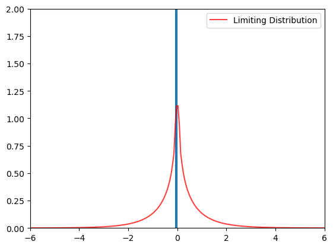

```python
N = 2_500
epsilon = 1e-4
us = np.linspace(epsilon, 1.0-epsilon, N)
zs = scipy.stats.norm.ppf(us)
samples = np.outer(zs, zs).flatten()

# Parameters
n_frames = 100
bins = 300

# Set up the figure, axis, and histogram
fig, ax = plt.subplots(1)
counts, bins, _ = ax.hist(samples, bins=bins, density=True, stacked=True)
midpoints = 0.5 * (bins[1:] + bins[:-1])
x_interp = np.linspace(midpoints[0], midpoints[-1], 500)
y_interp = np.interp(x_interp, midpoints, counts)

def product_of_normals_pdf(z, sigma=1, gamma=1):
    return (1.0 / (np.pi * sigma * gamma)) * k0(np.abs(z) / (sigma * gamma))

# Example usage:
import matplotlib.pyplot as plt

z = np.linspace(-6, 6, 400)

# Initialization function
def init():
    ax.clear()
    ax.hist(samples * std_fun(0), bins=bins, density=True, stacked=True)
    ax.set_xlim(-6, 6)
    ax.set_ylim(0, 2)
    ax.plot(x_interp, y_interp, '-r', label='Limiting Distribution', alpha=0.75)
    ax.legend()

# Update function
def update(frame):
    ax.clear()
    ax.hist(samples * std_fun(frame/10), bins=bins, density=True, stacked=True)
    ax.set_title(f"$t ={frame/10}$")
    ax.set_xlim(-6, 6)
    ax.set_ylim(0, 2)
    ax.plot(x_interp, y_interp, '-r', label='Limiting Distribution', alpha=0.75)
    ax.plot(z, product_of_normals_pdf(z, sigma=1, gamma=std_fun(frame/10)), '--g', label='Analytic', alpha=0.75)
    ax.legend()

# Create animation
ani = FuncAnimation(fig, update, frames=n_frames, init_func=init, repeat=False)
ani.save("animation_product.gif", writer=PillowWriter(fps=5))
```

$$ T_{t} \approx N\left(\mu(t), 2 \alpha \int_{0}^{t} \sigma^{2}(s)e^{2\alpha (s - t)}ds\right) + N(0, \chi^{2})N(0, 1). $$

Finally, if $T_{0} \sim N(\mu(t), \sigma^{2}(0))$ then we have,

\begin{align*} T_{t} &\sim N\left(\mu(t), e^{-2\alpha t} \sigma^{2}(0)+2\alpha \int_{0}^{t} \sigma^{2}(s) e^{2\alpha (s-t)} ds \right) + N(0, \chi^{2})\cdot N\left(0, 1 - \frac{e^{-2 t \beta} \alpha - e^{-2 t \alpha} \beta}{\alpha - \beta} \right) \\ &\approx N\left(\mu(t), 2\alpha \int_{0}^{t} \sigma^{2}(s) e^{2\alpha (s-t)} ds \right) + N(0, \chi^{2})\cdot N(0, 1). \end{align*}

# Variance of extra term

Let $X ~ N(0, \chi^{2})$, $Y\sim N(0, 1)$. These are mean zero, independent, stochastic processes. We can show therefore,

$$ \mathbb{E}[XY] = \mathbb{E}[X]\mathbb{E}[Y] = 0 \cdot 0 = 0. $$\begin{align*} \mathbb{V}[XY] &= \mathbb{E}[(XY)^{2}] - (\mathbb{E}[XY])^{2} = \mathbb{E}[X^{2}]\mathbb{E}[Y^{2}] - (\mathbb{E}[XY])^{2} = (\mathbb{V}[X] + (\mathbb{E}[X])^{2}) (\mathbb{V}[Y] + (\mathbb{E}[Y])^{2}) - (\mathbb{E}[XY])^{2} \\ &= \mathbb{V}[X]\mathbb{V}[Y] + \mathbb{V}[X]\mathbb{E}[Y]^{2} + \mathbb{V}[Y]\mathbb{E}[X]^{2} + \mathbb{E}[X]^{2}\mathbb{E}[Y]^{2} - (\mathbb{E}[XY])^{2} = \mathbb{V}[X]\mathbb{V}[Y]. \end{align*}

As $X,~Y$ are independent, mean zero. Furthermore, as the increments are independent, we have the two terms are independent, therefore the variance of $T_{t}$ is given by,

## Variance of the full process

$$ \mathbb{V}[T_{t}] = 2\alpha \int_{0}^{t} \sigma^{2}(s) e^{2\alpha (s - t)} ds + \chi^{2} \left(1 - \frac{e^{-2 t \beta} \alpha - e^{-2 t \alpha} \beta}{\alpha-\beta} \right) \approx 2\alpha \int_{0}^{t} \sigma^{2}(s) e^{2\alpha (s - t)} ds + \chi^{2}. $$

# Analytic Pricing

## PDF of the process

So we know have the pdf of the meteorlogical condition, under these stochastic dynamics.

$$ T_{t} \sim N\left(\mu(t), e^{-2\alpha t} \sigma^{2}(0)+2\alpha \int_{0}^{t} \sigma^{2}(s) e^{2\alpha (s-t)} ds \right) + N(0, \chi^{2})\cdot N\left(0, 1 - \frac{e^{-2 t \beta} \alpha - e^{-2 t \alpha} \beta}{\alpha - \beta} \right) .$$

We can show that the probability density of the second term $\epsilon_{t}\sim N(0, \chi^{2})\cdot N(0, \gamma^{2}) := N(0, \chi^{2}) \cdot N\left(0, 1 - \frac{e^{-2 t \beta} \alpha - e^{-2 t \alpha} \beta}{\alpha - \beta} \right)$, is specified by a modified Bessel function of order zero.

$$p_{\epsilon_{t}}(x) = \frac{1}{\pi\chi\gamma}K_{0}(\frac{|z|}{\chi\gamma}).$$

Of course, the first term is standard normal for which the density is known. Therefore, under this dynamics, we can express the distribution of temperatures on a given day, as we would in formulating the density of the sum of any random variables.

$$ p(x) = \int_{y = -\infty}^{\infty} p_{1}(y)p_{\epsilon_{t}}(x-y) dy $$

## Pricing

Under the real-world probability measure, using the fundamental theorem of asset pricing, we can price a call option as follows, with strike $K$, payoff per index tick $\nu$ and base temperature $18$,

\begin{align*} C(t) &= e^{-r(t_{0} - t)} \mathbb{E_{p}}\left[ \sum_{t_{i} = t_{0}}^{t} \nu\max\{T_{t_{i}} - K, 0\} \right] \\ &= \nu e^{-r(t_{0} - t)} \sum_{t_{i} = t_{0}}^{t} \mathbb{E_{p}}\left[\max\{T_{t_{i}} - K, 0\} \right] \\ &= \nu e^{-r(t_{0} - t)} \sum_{t_{i} = t_{0}}^{t} \int_{-\infty}^{K} p_{t_{i}}(x) (x - K) dx \end{align*}

And similarly for a put option:

\begin{align*} C(t) &= e^{-r(t_{0} - t)} \mathbb{E_{p}}\left[ \sum_{t_{i} = t_{0}}^{t} \nu\max\{K - T_{t_{i}}, 0\} \right] \\ &= \nu e^{-r(t_{0} - t)} \sum_{t_{i} = t_{0}}^{t} \mathbb{E_{p}}\left[\max\{K - T_{t_{i}}, 0\} \right] \\ &= \nu e^{-r(t_{0} - t)} \sum_{t_{i} = t_{0}}^{t} \int_{-\infty}^{K} p_{t_{i}}(x) (K - x) dx \end{align*}

# Todos

- Market Price of Risk $\lambda$ on similar to that paper under our model (Collect data from the same US weather stations)
- Plan next week correlations and introduce basis risk